# Relatório de Unidade - Autoavaliação UFRPE 2019 (UEDT)

# 1 INTRODUÇÃO

Este relatório apresenta as respostas dos discentes, docentes e técnicos da Unidade Acadêmica de Educação à Distância e Tecnologia (UAEADTEC), referente à autoavaliação 2019 da Universidade Federal Rural de Pernambuco (UFRPE), conduzida pela Comissão Própria de Avaliação (CPA). Neste ano foram contemplados dois eixos avaliativos: Planejamento e Avaliação Institucional e Desenvolvimento Institucional.

Esta avaliação foi feita a partir de questionários online, disponibilizados de forma voluntária aos discentes, docentes e técnicos da instituição, no período de 23 de abril a 29 de julho de 2019. Maiores detalhes sobre a metodologia de autoavaliação podem ser encontrados no 2º Relatório Parcial de Autoavaliação Institucional (ANO-BASE 2019), disponível no site da [CPA/UFRPE](http://cpa.ufrpe.br/br/relatorio-de-autoavaliacao-institucional/).

Note que este relatório apresenta os resultados da avaliação da UFRPE *como um todo* sob o ponto de vista dos membros desta unidade; sendo assim, não pode ser interpretado como uma avaliação da unidade propriamente dita.

# 2 PANORAMA

Dentre os membros da comunidade acadêmica desta unidade aptos a participar da avaliação, 37.35% dos estudantes responderam ao questionário (341 de 913), 78.95% dos docentes responderam ao questionário (30 de 38), e 92.86% dos técnicos responderam ao questionário (13 de 14).

Os gráficos a seguir apresentam os resultados da avaliação de alguns itens pré-selecionados: Ações de Planejamento de Cursos e Utilização dos Resultados da Autoavaliação Institucional no Planejamento de Cursos, além da atuação da UFRPE na promoção do desenvolvimento econômico e social, da sustentabilidade, da igualdade étnico-racial, e na valorização da diversidade.

*Por motivos técnicos, as respostas dos docentes EAD referentes às perguntas sobre desenvolvimento econômico e social, e também sobre sustentabilidade, não foram registradas pelo sistema de questionário. Por esse motivo, tais resultados não são apresentados neste relatório.*

[figure not shown]

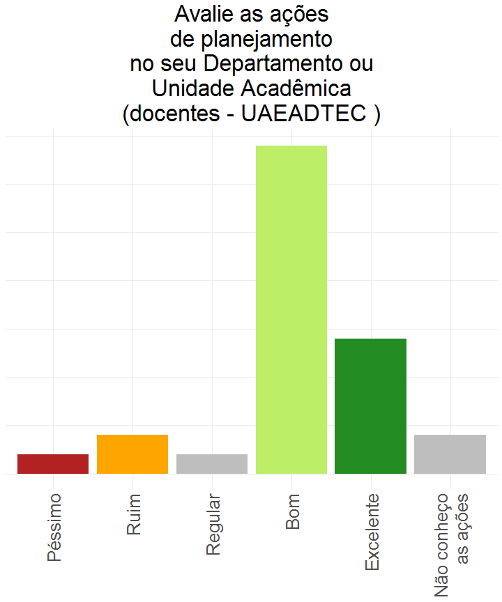

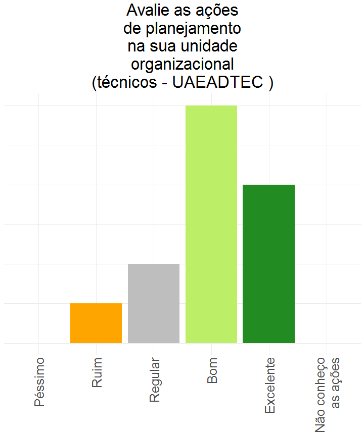

[figure not shown]

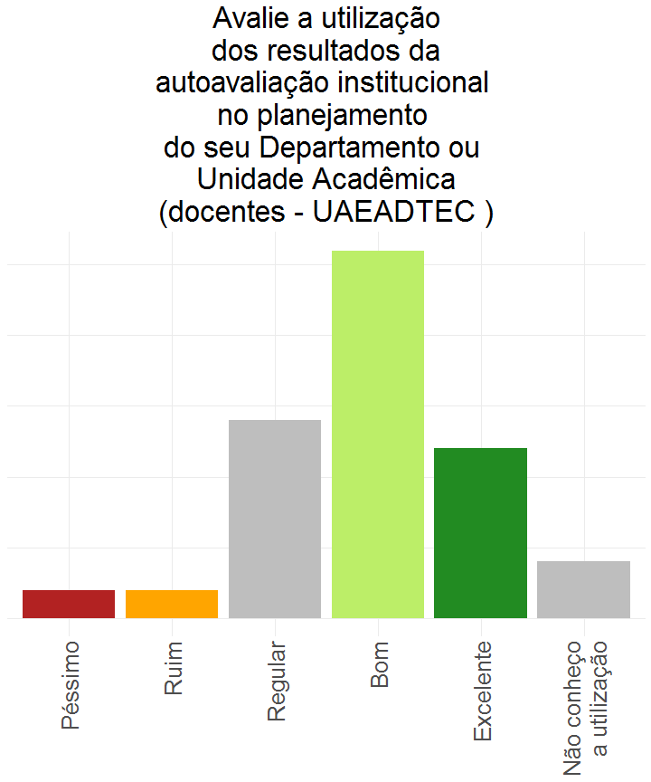

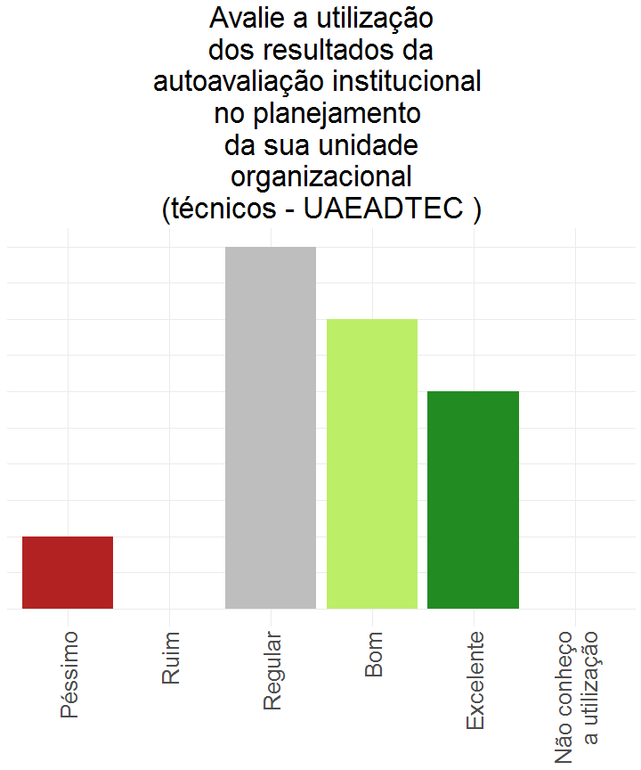

[figure not shown]

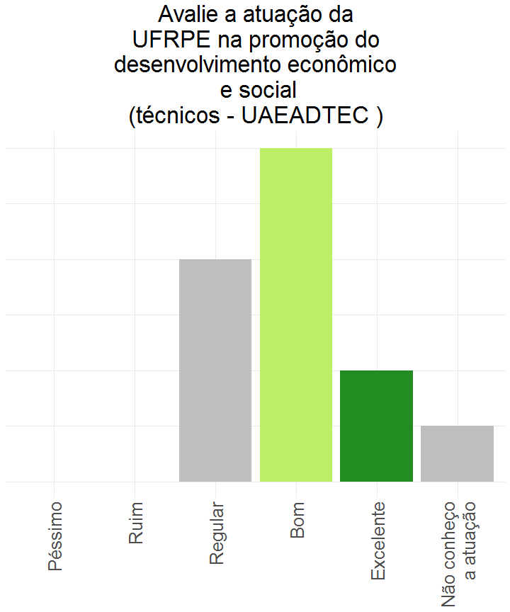

[figure not shown]

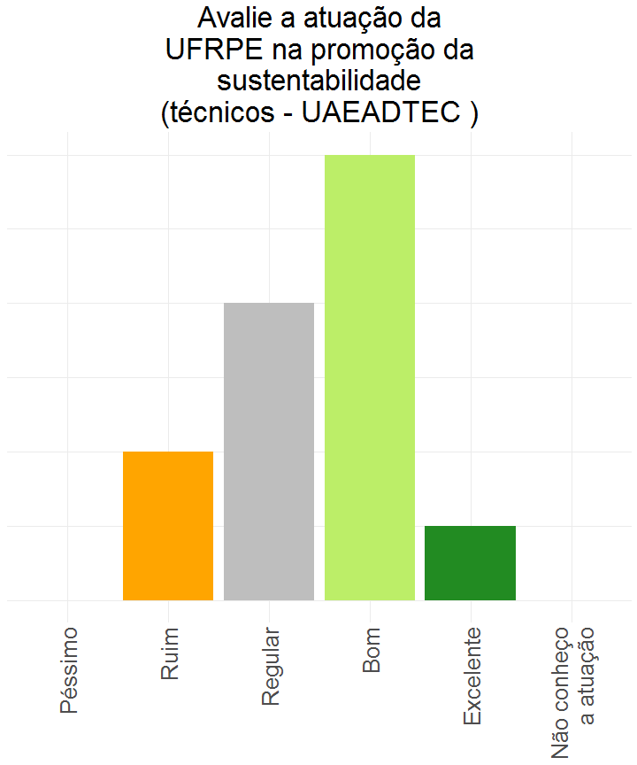

[figure not shown]

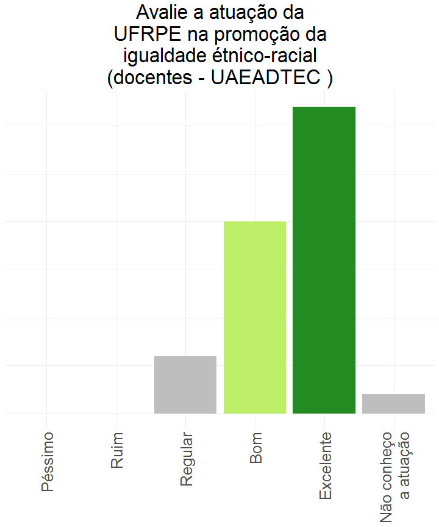

[4 more figures not shown]

# 3 DESTAQUES - PLANEJAMENTO E AVALIAÇÃO INSTITUCIONAL

Esta seção apresenta os resultados com maiores e menores médias numéricas referentes à avaliação do Planejamento e da Avaliação Institucional da UFRPE, conforme respondido pelos integrantes da Unidade Acadêmica de Educação à Distância e Tecnologia (UAEADTEC).

A seguir são apresentados os resultados classificados por segmento: discentes, docentes e técnicos.

## 3.1 Discentes (UAEADTEC)

Durante o período de avaliação esta unidade contava com 913 **discentes** aptos a participar da avaliação, dos quais 341 (37.35%) responderam ao questionário. Do total das respostas referentes a Planejamento e Avaliação da instituição, 1.32% foram “péssimo”, 3.57% foram “ruim”, 15.98% foram “regular”, 43.89% foram “bom”, 24.49% foram “excelente”, e 10.75% foram outras opções de resposta.

### 3.1.1 Maiores médias:

Lista das 3 perguntas com respostas mais positivas, de um total de 6 perguntas, com base na média ponderada das respostas dos discentes desta unidade acadêmica.

| Item | Média |
| --- | --- |
| Avalie o acesso ao atual questionário de autoavaliação da UFRPE no site da Comissão Própria de Avaliação (CPA) | 8.1 |
| Avalie o acesso aos relatórios de autoavaliação da UFRPE | 7.5 |
| Avalie o Projeto de Autoavaliação Institucional adotado pela Comissão Própria de Avaliação (CPA) | 7.5 |

### 3.1.2 Menores médias:

Lista das 3 perguntas com respostas mais negativas, de um total de 6 perguntas, com base na média ponderada das respostas dos discentes desta unidade.

| Item | Média |
| --- | --- |
| Avalie a visibilidade da Comissão Própria de Avaliação (CPA) nas Mídias Sociais (Facebook e Instagram) | 6.8 |
| Avalie a utilização dos resultados da autoavaliação institucional no planejamento do seu Curso | 7.2 |
| Avalie as ações de planejamento no seu curso | 7.3 |

## 3.2 Docentes (UAEADTEC)

Durante o período de avaliação esta unidade contava com 38 **docentes** aptos a participar da avaliação, dos quais 30 (78.95%) responderam ao questionário. Do total das respostas referentes a Planejamento e Avaliação da instituição, 1.11% foram “péssimo”, 2.22% foram “ruim”, 8.33% foram “regular”, 38.33% foram “bom”, 43.33% foram “excelente”, e 6.67% foram outras opções de resposta.

### 3.2.1 Maiores médias:

Lista das 3 perguntas com respostas mais positivas, de um total de 6 perguntas, com base na média ponderada das respostas dos docentes desta unidade acadêmica.

| Item | Média |
| --- | --- |
| Avalie o acesso a este questionário de autoavaliação da UFRPE no site da CPA | 9.6 |
| Avalie o acesso aos relatórios de autoavaliação da UFRPE | 8.8 |
| Avalie o Projeto de Autoavaliação Institucional adotado pela Comissão Própria de Avaliação (CPA) | 8.6 |

### 3.2.2 Menores médias:

Lista das 3 perguntas com respostas mais negativas, de um total de 6 perguntas, com base na média ponderada das respostas dos docentes desta unidade acadêmica.

| Item | Média |
| --- | --- |
| Avalie a utilização dos resultados da autoavaliação institucional no planejamento da Unidade Acadêmica | 7.0 |
| Avalie as ações de planejamento da Unidade Acadêmica | 7.4 |
| Avalie a visibilidade da Comissão Própria de Avaliação (CPA) nas Mídias Sociais (Facebook e Instagram) | 7.9 |

## 3.3 Técnicos (UAEADTEC)

Durante o período de avaliação esta unidade contava com 14 **técnicos** aptos a participar da avaliação, dos quais 13 (92.86%) responderam ao questionário. Do total das respostas referentes a Planejamento e Avaliação da instituição, 1.28% foram “péssimo”, 2.56% foram “ruim”, 15.38% foram “regular”, 47.44% foram “bom”, 26.92% foram “excelente”, e 6.41% foram outras opções de resposta.

### 3.3.1 Maiores médias:

Lista das 3 perguntas com respostas mais positivas, de um total de 6 perguntas, com base na média ponderada das respostas dos técnicos desta unidade acadêmica.

| Item | Média |
| --- | --- |
| Avalie o acesso a este questionário de autoavaliação da UFRPE no site da Comissão Própria de Avaliaação (CPA) | 8.8 |
| Avalie o acesso aos relatórios de autoavaliação da UFRPE | 7.9 |
| Avalie o Projeto de Autoavaliação Institucional adotado pela Comissão Própria de Avaliação (CPA) | 7.7 |

### 3.3.2 Menores médias:

Lista das 3 perguntas com respostas mais negativas, de um total de 6 perguntas, com base na média ponderada das respostas dos técnicos desta unidade acadêmica.

| Item | Média |
| --- | --- |
| Avalie a utilização dos resultados da autoavaliação institucional no planejamento de sua unidade organizacional | 6.5 |
| Avalie a visibilidade da Comissão Própria de Avaliação (CPA) nas Mídias Sociais (Facebook e Instagram) | 6.8 |
| Avalie as ações de planejamento na sua unidade organizacional | 7.5 |

# 4 DESTAQUES - DESENVOLVIMENTO INSTITUCIONAL

Esta seção apresenta os resultados com maiores e menores médias numéricas referentes à avaliação do Desenvolvimento Institucional da UFRPE, conforme respondido pelos integrantes da Unidade Acadêmica de Educação à Distância e Tecnologia (UAEADTEC).

A seguir são apresentados os resultados classificados por segmento: discentes, docentes e técnicos.

## 4.1 Discentes (UAEADTEC)

Durante o período de avaliação esta unidade contava com 913 **discentes** aptos a participar da avaliação, dos quais 341 (37.35%) responderam ao questionário. Do total das respostas referentes ao desenvolvimento institucional, 0.99% foram “péssimo”, 2.83% foram “ruim”, 13.65% foram “regular”, 40.02% foram “bom”, 27.78% foram “excelente”, e 14.74% foram outras opções de resposta.

### 4.1.1 Maiores médias:

Lista das 3 perguntas com respostas mais positivas, de um total de 11 perguntas, com base na média ponderada das respostas dos discentes desta unidade acadêmica.

| Item | Média |
| --- | --- |
| Avalie a atuação da UFRPE na promoção da igualdade étnico-racial | 8.4 |
| Avalie a atuação da UFRPE na promoção dos Direitos Humanos | 8.2 |
| Avalie a atuação da UFRPE na valorização da diversidade | 8.2 |

### 4.1.2 Menores médias:

Lista das 3 perguntas com respostas mais negativas, de um total de 11 perguntas, com base na média ponderada das respostas dos discentes desta unidade acadêmica.

| Item | Média |
| --- | --- |
| Avalie o seu conhecimento sobre o Plano de Desenvolvimento Institucional (PDI) | 6.5 |
| Avalie seu conhecimento sobre o Plano de Gestão de Logística Sustentável (PLS) da UFRPE | 7.0 |
| Avalie o alinhamento das diretrizes e objetivos estratégicos do Planod e Desenvolvimento Institucional (PDI) com as ações executadas na UFRPE | 7.1 |

## 4.2 Docentes (UAEADTEC)

Durante o período de avaliação esta unidade contava com 38 **docentes** aptos a participar da avaliação, dos quais 30 (78.95%) responderam ao questionário. Do total das respostas referentes ao desenvolvimento institucional, 0.37% foram “péssimo”, 3.7% foram “ruim”, 18.89% foram “regular”, 35.93% foram “bom”, 31.85% foram “excelente”, e 9.26% foram outras opções de resposta.

### 4.2.1 Maiores médias:

| Item | Média |
| --- | --- |
| Avalie a atuação da UFRPE na promoção da igualdade étnico-racial | 8.6 |
| Avalie a atuação da UFRPE na valorização da diversidade | 8.5 |
| Avalie a atuação da UFRPE na promoção dos Direitos Humanos | 8.4 |

### 4.2.2 Menores médias:

| Item | Média |
| --- | --- |
| Avalie seu conhecimento sobre o Plano de Gestão de Logística Sustentável (PLS) da UFRPE | 5.8 |
| Avalie a atuação da UFRPE na gestão do patrimônio cultural | 7.2 |
| Avalie a atuação da UFRPE na promoção da produção artística | 7.2 |

## 4.3 Técnicos (UAEADTEC)

Durante o período de avaliação esta unidade contava com 14 **técnicos** aptos a participar da avaliação, dos quais 13 (92.86%) responderam ao questionário. Do total das respostas referentes ao desenvolvimento institucional, 0% foram “péssimo”, 7.69% foram “ruim”, 14.69% foram “regular”, 43.36% foram “bom”, 11.19% foram “excelente”, e 23.08% foram outras opções de resposta.

### 4.3.1 Maiores médias:

Lista das 3 perguntas com respostas mais positivas, de um total de 11 perguntas, com base na média ponderada das respostas dos técnicos desta unidade acadêmica.

| Item | Média |
| --- | --- |
| Avalie a atuação da UFRPE na promoção da igualdade étnico-racial | 7.8 |
| Avalie a atuação da UFRPE na promoção dos Direitos Humanos | 7.5 |
| Avalie a atuação da UFRPE na valorização da diversidade | 7.5 |

### 4.3.2 Menores médias:

Lista das 3 perguntas com respostas mais negativas, de um total de 11 perguntas, com base na média ponderada das respostas dos técnicos desta unidade acadêmica.

| Item | Média |
| --- | --- |
| Avalie o alinhamento das diretrizes e objetivos estratégicos do Plano de Desenvolvimento Institucional (PDI) com as ações executadas na UFRPE | 6.1 |
| Avalie a atuação da UFRPE na gestão do patrimônio cultural | 6.2 |
| Avalie a atuação da UFRPE na promoção da sustentabilidade | 6.2 |

# 5 RESULTADOS COMPLETOS

Esta seção apresenta as tabelas com as respostas a todas as perguntas do questionário de avaliação UFRPE 2019, conforme respondido pelos integrantes desta unidade, classificadas por segmento.

## 5.1 Planejamento e Avaliação Institucional

### 5.1.1 Discentes (UAEADTEC)

Resultados da avaliação de **Planejamento e Avaliação Institucional** da UFRPE, conforme respondido pelos discentes desta unidade acadêmica.

| Média | Item | Péssimo (0) | Ruim (2.5) | Regular (5) | Bom (7.5) | Excelente (10) | OOR* |
| --- | --- | --- | --- | --- | --- | --- | --- |
| 8.1 | Avalie o acesso ao atual questionário de autoavaliação da UFRPE no site da Comissão Própria de Avaliação (CPA) | 1 | 7 | 29 | 176 | 128 | 0 |
| 7.5 | Avalie o acesso aos relatórios de autoavaliação da UFRPE | 4 | 10 | 48 | 159 | 84 | 36 |
| 7.5 | Avalie o Projeto de Autoavaliação Institucional adotado pela Comissão Própria de Avaliação (CPA) | 4 | 9 | 53 | 145 | 78 | 52 |
| 7.3 | Avalie as ações de planejamento no seu curso | 8 | 17 | 59 | 155 | 87 | 15 |
| 7.2 | Avalie a utilização dos resultados da autoavaliação institucional no planejamento do seu Curso | 5 | 13 | 63 | 147 | 72 | 41 |
| 6.8 | Avalie a visibilidade da Comissão Própria de Avaliação (CPA) nas Mídias Sociais (Facebook e Instagram) | 5 | 17 | 75 | 116 | 52 | 76 |

*OOR: Outras opções de resposta

### 5.1.2 Docentes (UAEADTEC)

Resultados da avaliação de Planejamento e Avaliação Institucional da UFRPE, conforme respondido pelos docentes desta unidade acadêmica.

| Média | Item | Péssimo (0) | Ruim (2.5) | Regular (5) | Bom (7.5) | Excelente (10) | OOR* |
| --- | --- | --- | --- | --- | --- | --- | --- |
| 9.6 | Avalie o acesso a este questionário de autoavaliação da UFRPE no site da CPA | 0 | 0 | 0 | 5 | 25 | 0 |
| 8.8 | Avalie o acesso aos relatórios de autoavaliação da UFRPE | 0 | 0 | 1 | 10 | 15 | 4 |
| 8.6 | Avalie o Projeto de Autoavaliação Institucional adotado pela Comissão Própria de Avaliação (CPA) | 0 | 0 | 2 | 12 | 14 | 2 |
| 7.9 | Avalie a visibilidade da Comissão Própria de Avaliação (CPA) nas Mídias Sociais (Facebook e Instagram) | 0 | 1 | 4 | 12 | 11 | 2 |
| 7.4 | Avalie as ações de planejamento da Unidade Acadêmica | 1 | 2 | 1 | 17 | 7 | 2 |
| 7.0 | Avalie a utilização dos resultados da autoavaliação institucional no planejamento da Unidade Acadêmica | 1 | 1 | 7 | 13 | 6 | 2 |

*OOR: Outras opções de resposta

### 5.1.3 Técnicos (UAEADTEC)

Resultados da avaliação de Planejamento e Avaliação Institucional da UFRPE, conforme respondido pelos técnicos desta unidade acadêmica.

| Média | Item | Péssimo (0) | Ruim (2.5) | Regular (5) | Bom (7.5) | Excelente (10) | OOR* |
| --- | --- | --- | --- | --- | --- | --- | --- |
| 8.8 | Avalie o acesso a este questionário de autoavaliação da UFRPE no site da Comissão Própria de Avaliaação (CPA) | 0 | 0 | 2 | 2 | 9 | 0 |
| 7.9 | Avalie o acesso aos relatórios de autoavaliação da UFRPE | 0 | 0 | 1 | 8 | 3 | 1 |
| 7.7 | Avalie o Projeto de Autoavaliação Institucional adotado pela Comissão Própria de Avaliação (CPA) | 0 | 0 | 0 | 10 | 1 | 2 |
| 7.5 | Avalie as ações de planejamento na sua unidade organizacional | 0 | 1 | 2 | 6 | 4 | 0 |
| 6.8 | Avalie a visibilidade da Comissão Própria de Avaliação (CPA) nas Mídias Sociais (Facebook e Instagram) | 0 | 1 | 2 | 7 | 1 | 2 |
| 6.5 | Avalie a utilização dos resultados da autoavaliação institucional no planejamento de sua unidade organizacional | 1 | 0 | 5 | 4 | 3 | 0 |

*OOR: Outras opções de resposta

## 5.2 Desenvolvimento Institucional

### 5.2.1 Discentes (UAEADTEC)

Resultados da avaliação do **Desenvolvimento Institucional** da UFRPE, conforme respondido pelos discentes desta unidade acadêmica.

| Média | Item | Péssimo (0) | Ruim (2.5) | Regular (5) | Bom (7.5) | Excelente (10) | OOR* |
| --- | --- | --- | --- | --- | --- | --- | --- |
| 8.4 | Avalie a atuação da UFRPE na promoção da igualdade étnico-racial | 2 | 3 | 24 | 138 | 147 | 27 |
| 8.2 | Avalie a atuação da UFRPE na promoção dos Direitos Humanos | 3 | 4 | 28 | 141 | 134 | 31 |
| 8.2 | Avalie a atuação da UFRPE na valorização da diversidade | 2 | 6 | 25 | 147 | 134 | 27 |
| 7.9 | Avalie a atuação da UFRPE na promoção da sustentabilidade | 3 | 6 | 43 | 140 | 117 | 32 |
| 7.9 | Avalie a atuação da UFRPE na promoção do desenvolvimento econômico e social | 6 | 9 | 35 | 147 | 118 | 26 |
| 7.8 | Avalie a atuação da UFRPE na gestão do patrimônio cultural | 3 | 7 | 49 | 135 | 104 | 43 |
| 7.6 | Avalie a atuação da UFRPE na promoção da produção artística | 4 | 7 | 54 | 146 | 87 | 43 |
| 7.2 | Avalie o Plano de Desenvolvimento Institucional (PDI) da UFRPE como instrumento de gestão ( Planejamento, execução e avaliação) | 3 | 14 | 46 | 149 | 54 | 75 |
| 7.1 | Avalie o alinhamento das diretrizes e objetivos estratégicos do Planod e Desenvolvimento Institucional (PDI) com as ações executadas na UFRPE | 4 | 10 | 57 | 138 | 50 | 82 |
| 7.0 | Avalie seu conhecimento sobre o Plano de Gestão de Logística Sustentável (PLS) da UFRPE | 2 | 17 | 64 | 101 | 60 | 97 |
| 6.5 | Avalie o seu conhecimento sobre o Plano de Desenvolvimento Institucional (PDI) | 5 | 23 | 87 | 119 | 37 | 70 |

*OOR: Outras opções de resposta

### 5.2.2 Docentes (UAEADTEC)

Resultados da avaliação do Desenvolvimento Institucional da UFRPE, conforme respondido pelos docentes desta unidade acadêmica.

| Média | Item | Péssimo (0) | Ruim (2.5) | Regular (5) | Bom (7.5) | Excelente (10) | OOR* |
| --- | --- | --- | --- | --- | --- | --- | --- |
| 8.6 | Avalie a atuação da UFRPE na promoção da igualdade étnico-racial | 0 | 0 | 3 | 10 | 16 | 1 |
| 8.5 | Avalie a atuação da UFRPE na valorização da diversidade | 0 | 0 | 4 | 9 | 16 | 1 |
| 8.4 | Avalie a atuação da UFRPE na promoção dos Direitos Humanos | 0 | 0 | 5 | 9 | 15 | 1 |
| 7.6 | Avalie o Plano de Desenvolvimento Institucional (PDI) da UFRPE como instrumento de gestão ( Planejamento, execução e avaliação) | 0 | 0 | 7 | 12 | 8 | 3 |
| 7.4 | Avalie o seu conhecimento sobre o Plano de Desenvolvimento Institucional (PDI) | 0 | 2 | 5 | 12 | 8 | 3 |
| 7.3 | Avalie o alinhamento das diretrizes e objetivos estratégicos do Plano de Desenvolvimento Institucional (PDI) com as ações executadas na UFRPE | 0 | 0 | 7 | 14 | 5 | 4 |
| 7.2 | Avalie a atuação da UFRPE na gestão do patrimônio cultural | 0 | 3 | 3 | 18 | 5 | 1 |
| 7.2 | Avalie a atuação da UFRPE na promoção da produção artística | 0 | 3 | 6 | 10 | 9 | 2 |
| 5.8 | Avalie seu conhecimento sobre o Plano de Gestão de Logística Sustentável (PLS) da UFRPE | 1 | 2 | 11 | 3 | 4 | 9 |

*OOR: Outras opções de resposta

### 5.2.3 Técnicos (UAEADTEC)

Resultados da avaliação do Desenvolvimento Institucional da UFRPE, conforme respondido pelos técnicos desta unidade acadêmica.

| Média | Item | Péssimo (0) | Ruim (2.5) | Regular (5) | Bom (7.5) | Excelente (10) | OOR* |
| --- | --- | --- | --- | --- | --- | --- | --- |
| 7.8 | Avalie a atuação da UFRPE na promoção da igualdade étnico-racial | 0 | 0 | 1 | 7 | 2 | 3 |
| 7.5 | Avalie a atuação da UFRPE na promoção dos Direitos Humanos | 0 | 1 | 0 | 7 | 2 | 3 |
| 7.5 | Avalie a atuação da UFRPE na valorização da diversidade | 0 | 0 | 2 | 7 | 2 | 2 |
| 7.1 | Avalie a atuação da UFRPE na promoção do desenvolvimento econômico e social | 0 | 0 | 4 | 6 | 2 | 1 |
| 7.0 | Avalie o seu conhecimento sobre o Plano de Desenvolvimento Institucional (PDI) | 0 | 1 | 2 | 5 | 2 | 3 |
| 6.9 | Avalie o Plano de Desenvolvimento Institucional (PDI) da UFRPE como instrumento de gestão ( Planejamento, execução e avaliação) | 0 | 1 | 2 | 4 | 2 | 4 |
| 6.7 | Avalie a atuação da UFRPE na promoção da produção artística | 0 | 2 | 0 | 7 | 1 | 3 |
| 6.7 | Avalie seu conhecimento sobre o Plano de Gestão de Logística Sustentável (PLS) da UFRPE | 0 | 1 | 1 | 3 | 1 | 7 |
| 6.2 | Avalie a atuação da UFRPE na gestão do patrimônio cultural | 0 | 2 | 2 | 5 | 1 | 3 |
| 6.2 | Avalie a atuação da UFRPE na promoção da sustentabilidade | 0 | 2 | 4 | 6 | 1 | 0 |
| 6.1 | Avalie o alinhamento das diretrizes e objetivos estratégicos do Plano de Desenvolvimento Institucional (PDI) com as ações executadas na UFRPE | 0 | 1 | 3 | 5 | 0 | 4 |

*OOR: Outras opções de resposta